# presentation slides

[figure not shown]

--- # Ciência de Dados ## Modelos Preditivos ### Prof. Carlos Andres Ferrero ### *Beers for Devs - Bate Papo, Tecnologia e Cerveja* ---

## Tópicos

- Apresentação
- Ciência de Dados
- O que são modelos?
- Texto, Imagens, Dados Temporais e Trajetórias
- Caminhos e oportunidades de formação

## Vida e Formação

- Natural da Argentina. Residente no Brasil desde 2002, aos 15~16 anos de idade
- **Graduação em Ciência da Computação (2003 - 2006)**
  - Instituição: Universidade Estadual do Oeste do Paraná (UNIOESTE)
  - Atividades em um Laboratório de Pesquisa de Informática Médica (2004-2013)
  - Temas: mineração de textos, de imagens e de dados temporais
- **Mestrado em Ciência da Computação e Matemática Computacional (2007-2009)**
  - Instituição: Instituto de Ciências Matemáticas e de Computação (ICMC), Universidade de São Paulo (USP)
  - Atividades no Laboratório de Inteligência Computacional (LABIC)
  - Temas: predição de dados temporais
- Professor e pesquisador na UNIOESTE, campus Foz do Iguaçu (2009-2014)
- Professor e pesquisador no IFSC, campus Lages (desde 2014)
- **Doutorando em Ciência da Computação (2015-2020)**
  - Instituição: Univerisdade Federal de Santa Catarina (UFSC)
  - Temas: classificação de dados espaço-temporais (trajetórias)

## Atividades Atuais

- **Professor e pesquisador** no Instituto Federal de Santa Catarina (IFSC), campus Lages
  - Disciplinas de Mineração de Dados, Tópicos Especiais em IA e algumas de Desenvolvimento Web
- **Grupos de Pesquisa**:
  - Participante - Inteligência Computacional (USP/São Carlos) desde 2009
  - Participante - Inteligência Computacional e Inserção Tecnológica (UNILA/Foz do Iguaçu) desde 2017
  - Lider - Análise Inteligente de Dados (IFSC/Lages) desde 2014
- **Projetos em Ciência de Dados**:
  - Master: Multiple ASpects TrajEctoRy Mangement and Analysis (Projeto Europeu H2020-MSCA-RISE-2017)
  - Predição de Risco de Evasão de Alunos usando Métodos de Inteligência Artificial (IFSC)
  - Métodos Computacionais aplicados à Fiscalização de Tributos (IFSC, SISAMA, RF)
  - *Sistema de Gerenciamento de Dados com Suporte a Reconhecimento Facial e de Impressão Digital (IFSC, DEAP)
- **Revisor de Periódicos e Integrante de Comite de Programa**:
  - *Geographical Information Analytics* (GIA), *Symposium on Applied Computing* (SAC) - Qualis A1
  - *Knowledge Based Systems Journal* (KBS) - Qualis A1
  - *Future Internet* e *Scientific Annals of Computer Science* - Sem qualis

## Ciência de Dados

- Uma **evolução** da área de **Mineração de Dados** que conquistou o mercado e a academia.
- Popularização das técnicas de análise de dados, que até então ficavam, em geral, na academia
- Envolve muitas áreas básicas e aplicadas como:
  - Matemática e Estatística
  - Visualização de Dados
  - Machine Learning
  - Big Data
  - Linguagens de Programação (Python, R, ...)
  - Domínio de aplicação (Negócios, Medicina, Biologia, ...)
  - ...

### Processos de Mineração de Dados

[figure not shown]

- [Discussão da relação entre KDD e CRISP-DM](http://www.datascience-pm.com/crisp-dm-and-kdd/)

### Processo de Ciência de Dados - Mais recente

[figure not shown]

## O Que São Modelos?

**Um Exemplo**

Uma empresa que vende cervejas possui milhares rótulos. Obter opiniões confiáveis de clientes é custoso. A empresa fez um investimento para obter 300 avaliações de clientes sobre diferentes cervejas. No sistema de avaliação de produtos os clientes avaliam cada cerveja com as opções: **Compraria** ou **Nao Compararia**.

**Problema**

A empresa gostaria de saber se dadas as características de uma cerveja, é possível estimar se seria comprada pelos clientes ou não.

**Coleta de Dados**

Das cervejas avaliadas pelos clientes a empresa coletou as características: **Alcool** (teor alcoólico) e **IBUs** (unidades de amargor).

Em Aprendizado Supervisionado, os **modelos** são funções que tentar predizer um objetivo.

*Aprendizado supervisionado* é tipo de técnica de *Machine Learning* usada quando temos instâncias rotuladas do que queremos prever. Por exemplo, a empresa tem 300 instâncias de cervejas avaliadas pelos clientes.

**Conjunto de Dados**

O conjunto de dados tem 300 avaliações. Mostramos aqui as primeiras 20.

```python
data1.round(2).head(20)
```

|  | Alcool | IBUs | target |
| --- | --- | --- | --- |
| 0 | 5.09 | 9.77 | Compraria |
| 1 | 7.48 | 6.64 | Compraria |
| 2 | 7.74 | 20.00 | Não compraria |
| 3 | 9.51 | 12.69 | Não compraria |
| 4 | 9.73 | 13.63 | Não compraria |
| 5 | 10.19 | 13.69 | Não compraria |
| 6 | 6.33 | 5.42 | Compraria |
| 7 | 10.71 | 11.44 | Não compraria |
| 8 | 8.54 | 15.77 | Não compraria |
| 9 | 5.93 | 7.84 | Compraria |
| 10 | 6.16 | 8.12 | Compraria |
| 11 | 8.47 | 9.10 | Compraria |
| 12 | 11.64 | 13.61 | Não compraria |
| 13 | 5.12 | 7.31 | Compraria |
| 14 | 4.96 | 7.55 | Compraria |
| 15 | 9.80 | 12.50 | Não compraria |
| 16 | 7.58 | 8.50 | Não compraria |
| 17 | 3.00 | 1.83 | Compraria |
| 18 | 9.90 | 12.63 | Não compraria |
| 19 | 6.37 | 7.62 | Compraria |

**Visualização de Dados**

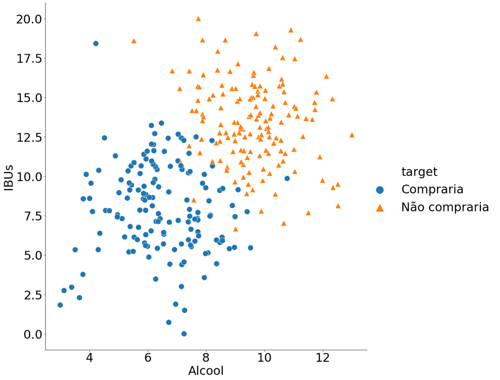

```python
plt.rcParams.update({'font.size': 30})
plt.rcParams.update({'legend.markerscale': 3.0})
sns.relplot(x='Alcool', y='IBUs', hue='target', style = "target", markers = ['o','^'], data = data1, height=14, s=200)
```

**Modelagem**

Considere $x_1 = \text{Alcool}$ e $x_2 = \text{IBUs}$. Vamos ajustar um modelo tem o seguinte formato:

$$ f(x_1, x_2) = w_1 * x_1 + w_2 * x_2 + b$$

O modelo vai assumir que:

- Os valores **Negativos** se referem a **Compraria**
- Os valores **Positivos** se referem a **Não compraria**

O valor de $w_1$ é o **peso** do *Alcool* na escolha de compra.

O valor de $w_2$ é o **peso** de *IBUs* na escolha de compra.

**Procurando uma Boa Solução**

```python
display(ui, out)
```

Um método chamado de Regressão Logística consegue encontrar os melhores valores para essa função:

- $w_1 = 0.53$
- $w_2 = 0.25$
- $b = - 6.70$

Assim, o **modelo** para predizer se os clientes vão **comprar uma cerveja ou não** é dado por:

$$ f(\text{Alcool}, \text{IBUs}) = 0.53 * \text{Alcool} + 0.25 * \text{IBUs} - 6.70 $$

- Valores **Negativos** se referem a **Compraria**
- Valores **Positivos** se referem a **Não compraria**

**Outros Modelos**: *k-Nearest Neighbors*

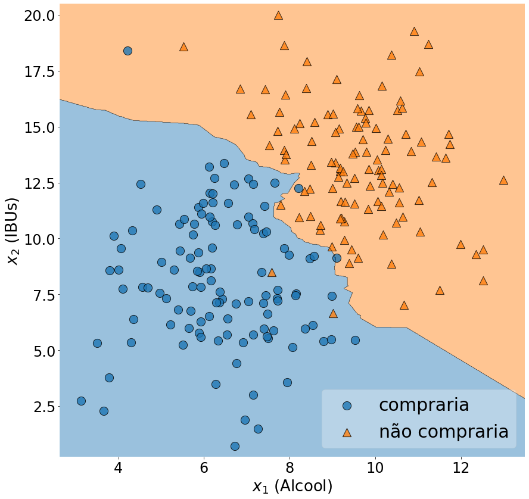

```python
from sklearn.neighbors import KNeighborsClassifier
model_knn = KNeighborsClassifier(n_neighbors=3)
model_knn.fit(X_train,y_train)
fig, ax = plt.subplots(figsize=(14, 14))
plt.rcParams.update({'font.size': 30})
plt.rcParams.update({'legend.markerscale': 1.0})
plot_decision_regions(X_train.to_numpy(), y_train, clf=model_knn, legend=1, ax= ax, markers = ['o','^'], zoom_factor = 2, scatter_kwargs = {'s': 200})
handles, labels = ax.get_legend_handles_labels()
ax.legend(handles, ['compraria','não compraria'], framealpha=0.3, scatterpoints=1, loc='lower right')
ax.set_xlabel(r'$x_1$ (Alcool)',fontsize=26)
ax.tick_params(axis='both', which='major', labelsize=24)
ax.set_ylabel(r'$x_2$ (IBUs)',fontsize=26)
plt.show()
```

**Outros Modelos**: *Decision Trees*

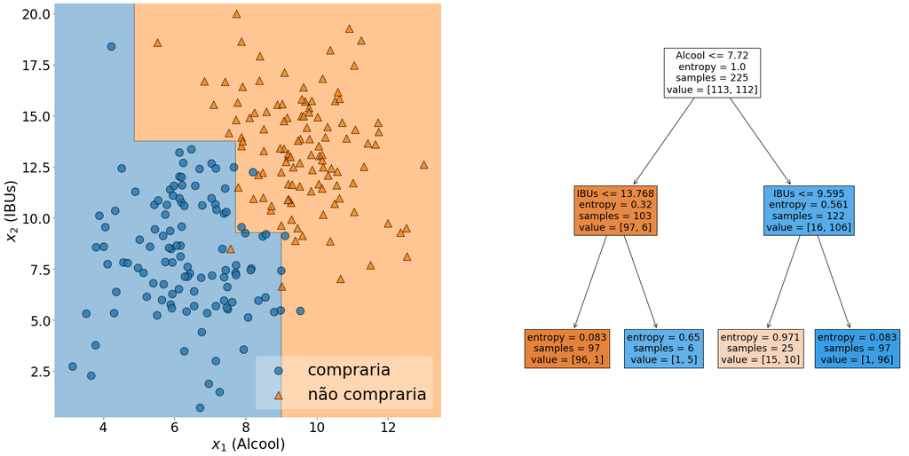

```python
from sklearn.tree import DecisionTreeClassifier
from sklearn.tree import plot_tree

model_dt = DecisionTreeClassifier(criterion="gini", max_depth=3)
model_dt.fit(X_train,y_train)
fig, ax = plt.subplots(1,2,figsize=(28, 14))
model_dt1 = DecisionTreeClassifier(criterion="entropy", max_depth=2)
model_dt1.fit(X_train,y_train)
plot_tree(model_dt1, filled=True, feature_names = X.columns, ax=ax[1])
plt.rcParams.update({'font.size': 30})
plt.rcParams.update({'legend.markerscale': 1.0})
plot_decision_regions(X_train.to_numpy(), y_train, clf=model_dt, legend=1, ax= ax[0], markers = ['o','^'], zoom_factor = 2, scatter_kwargs = {'s': 200})
handles, labels = ax[0].get_legend_handles_labels()
ax[0].legend(handles, ['compraria','não compraria'], framealpha=0.3, scatterpoints=1, loc='lower right')
ax[0].set_xlabel(r'$x_1$ (Alcool)',fontsize=26)
ax[0].tick_params(axis='both', which='major', labelsize=24)
ax[0].set_ylabel(r'$x_2$ (IBUs)',fontsize=26)
plt.show()
```

## Texto, Imagens, Dados Temporais, Trajetórias

Estes tipos de dados estão super na moda atualmente. Vejam como as coisas se complicam:

## - **Texto**: *e se cada cliente que avaliou uma cerveja ao fez um comentário próprio de até 400 caracteres sobre a mesma? e se fez uma postagem nas redes sociais a respeito?*

## - **Imagens**: *e se tivessemos accesso ao rosto do cliente quando ele experimentou a cerveja? ou uma foto na postagem da rede social? qual sentimento poderia ser extraído?*

## - **Dados Temporais**: *e se soubéssemos o histórico (marca, tipo, ...) de consumo de cervejas desses clientes?*

- **Trajetórias**: *e se soubéssemos os locais e horários em que o cliente bebe cerveja? o que poderíamos oferecer? será que eles bebem após trabalhar ou estudar, quando viajam para outra cidade?*

## Caminhos e Oportunidades de Formação em Ciência de Dados

- Cursos Online Free/Pagos
  - Algebra, Cálculo e Cálculo Numérico (free) - Khan Academy https://www.khanacademy.org/
  - Ciência de Dados
    - Udacity
      - Intro to Data Science (free)
      - Data Science
    - Coursera (free)
  - Deep Learning
    - Coursera (free)
    - Udacity

**Oportunidades de Formação no Instituto Federal de Santa Catarina (IFSC/Lages)**

- Matrícula em Disciplina Isolada para Graduados ou Graduandos
- Portador de Diploma para Graduados (no inicio de cada semestre)
- SISU para não graduados
- Disciplinas:
  - Mineração de Dados*
  - Inteligência Artificial*
  - Tópicos Especiais em IA*
  - Estatística*
  - Cálculo Numérico
  - Álgebra e Geometria Analítica
  - Cálculo

[figure not shown]

--- # Ciência de Dados ## Modelos Preditivos ### Prof. Carlos Andres Ferrero ### *Beers for Devs - Bate Papo, Tecnologia e Cerveja* ---